# Data Visualization with ggplot2 (Part 2)

#### **Example2: mtcars**

Just now we saw why **“dynamite plots”** (bar plots with error bars) are not well suited for their intended purpose of depicting distributions.  
If you really want that, you can still get dynamite plots. However, you’ll need to set the positions manually.  
A point geom will typically serve you much better.

It would be nice to give an impression of the number of values in each group here.

```r
# Tidy data first.
mtcars.cyl <- mtcars %>%
  group_by(factor(cyl)) %>%
  summarize(wt.avg = mean(wt), sd = sd(wt), n())
colnames(mtcars.cyl)[c(1, 4)] <- c('Cylinders', 'n')
mtcars.cyl <- mutate(mtcars.cyl, prop = n/sum(n))
mtcars.cyl
```

```
## # A tibble: 3 x 5
##   Cylinders wt.avg    sd     n  prop
##   <fct>      <dbl> <dbl> <int> <dbl>
## 1 4           2.29 0.570    11 0.344
## 2 6           3.12 0.356     7 0.219
## 3 8           4.00 0.759    14 0.438
```

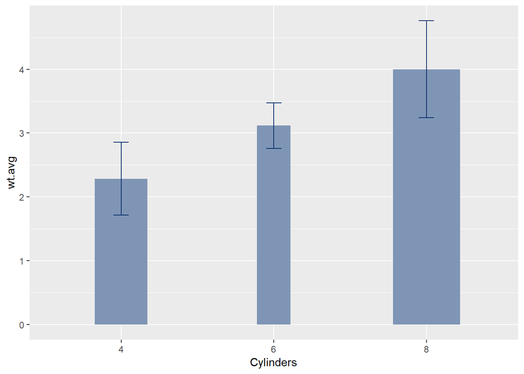

```r
ggplot(mtcars.cyl, aes(x = Cylinders, y = wt.avg)) +
  geom_col(width = mtcars.cyl$prop, fill = '#7F95B5') +
  geom_errorbar(aes(ymin = wt.avg - sd, ymax = wt.avg + sd), width = 0.1, col = '#08306B')
```

## Pie Charts & Alternatives

- In **Coordinates - Pie Charts**, we’ve discussed how a pie chart is simply a stacked bar chart plotted onto **polar coordinates.**
- When it comes to deciphering a pie chart, people will use angle, area or arc length.
- All of them are all mediocre encoding elements, so none of them are really ideal.
  - Reference: **[Which Kind of Aesthetics? For Continuous Variables](https://bourbon0212.github.io/NTU-CS-X/Week2/Data_Visualization_with_ggplot2__Part_1_.html#3.4.1)**
- We can’t control which one readers may choose which may cause ambiguity.
- The only instance where pie charts are suitable is for representing large quantitative at most three groups.

To be brief, here are cons of using pie charts:

- 3+ pie charts -> **Unefficient**.
- Many unideal ways to encode -> **Cause ambiguity**.

#### **Example: HairCol**

Here is the original bar blot for hair color.

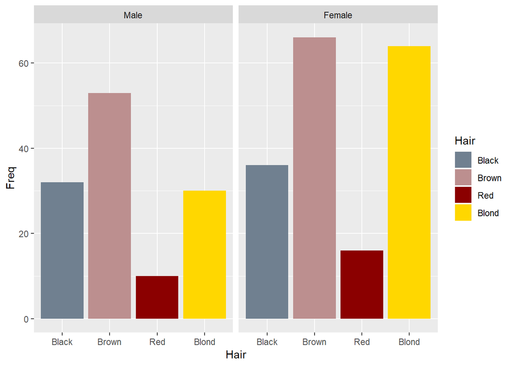

```r
HairCol <- as.data.frame(HairEyeColor)
ggplot(HairCol, aes(x = Hair, y = Freq, fill = Hair)) +
  scale_fill_manual('Hair', values = c('slategray', 'rosybrown', 'darkred', 'gold')) +
  geom_col(position = 'dodge') +
  facet_grid(.~Sex)
```

This is the pie chart version of this data.  
There are only two charts so it might not seem that much annoying.  
However, imagine that you have lots of pie charts, how could you compare the statistics?

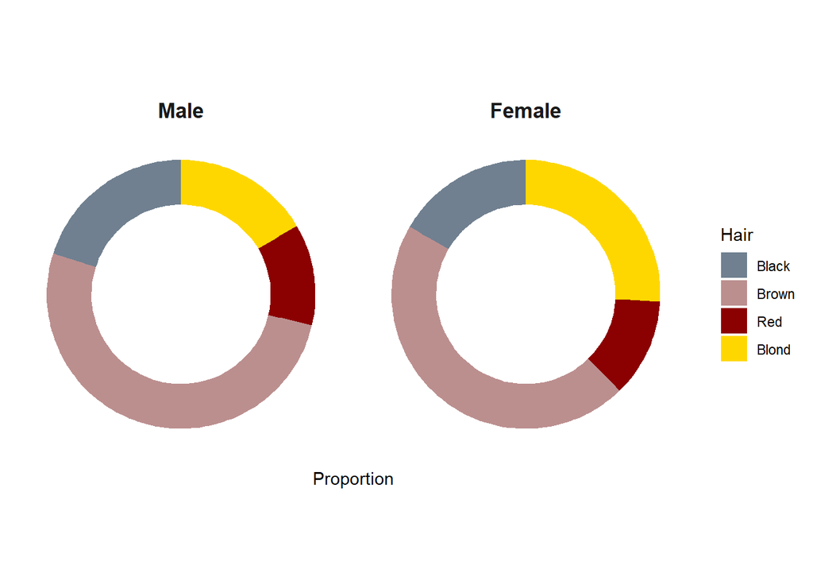

```r
plot10 <- ggplot(HairCol, aes(x = 1, y = Freq, fill = Hair)) +
  scale_fill_manual('Hair', values = c('slategray', 'rosybrown', 'darkred', 'gold')) +
  scale_y_continuous('Proportion') +
  theme_classic() +
  theme(rect = element_blank(),
        strip.text = element_text(size = 13, face = 'bold'))

plot10 +
  geom_col(position = 'fill', width = 0.2) +
  scale_x_continuous(limits = c(0.5, 1.1)) +
  coord_polar(theta = 'y') +
  facet_grid(.~Sex) +
  theme(axis.title.y = element_blank(),
        line = element_blank(),
        axis.text = element_blank())
```

The preferred way is **‘Fill’** bar plot here.  
No matter how many plots you have, it’s much easier to make a comparison.

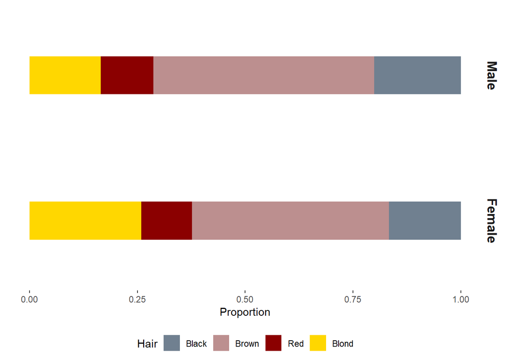

```r
plot10 +
  geom_col(position = 'fill', width = 0.3) +
  scale_x_continuous(limits = c(0.5, 1.5)) +
  coord_flip() +
  facet_grid(Sex~.) +
  theme(axis.title.y = element_blank(),
        axis.line = element_blank(),
        axis.ticks.y = element_blank(),
        axis.text.y = element_blank(),
        legend.position = 'bottom',
        legend.direction= 'horizontal')
```

## Heat Maps & Alternatives

Heat maps are a surprisingly popular choice for data visualization, but they are probably one of the **least** effective types of visualization.

- Our perception changes dependent on the neighboring colors.
- Heat map only has `color` for variables which is hard to recognize.
- Look fancy and complicated - signs of poor communication skills.
- As a result, basically **NO** meaningful information in heat map.

Let’s see some alternatives.

#### **Example: Barley Yields**

The dataset we’re using here is about the yield of some varieties of barley in different site in 1931 & 1932.  
We should call it out by `library(lattice)`.

```r
library(lattice)
head(barley)
```

```
##      yield   variety year            site
## 1 27.00000 Manchuria 1931 University Farm
## 2 48.86667 Manchuria 1931          Waseca
## 3 27.43334 Manchuria 1931          Morris
## 4 39.93333 Manchuria 1931       Crookston
## 5 32.96667 Manchuria 1931    Grand Rapids
## 6 28.96667 Manchuria 1931          Duluth
```

Use `geom_tile()` to make a heat map.  
See? It doesn’t provide any meaningful information at first glance.  
We use `scale_fill_gradientn()` to fill in continuous variables.

- `scale_fill_brewer(palette = "*")`, `scale_fill_manual('col_name', values = *)` for discrete variables.

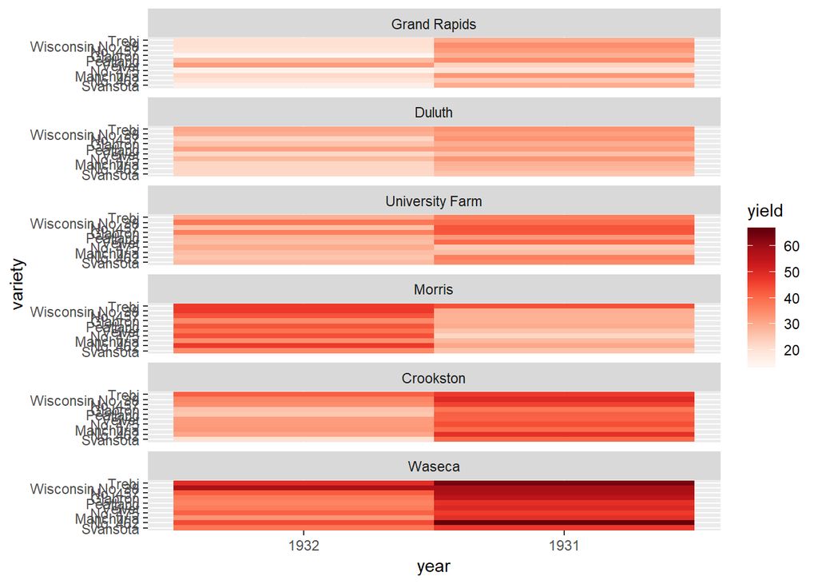

```r
ggplot(barley, aes(x = year, y = variety, fill = yield)) +
  geom_tile() + # Geom layer
  facet_wrap( ~ site, ncol = 1) + # Facet layer
  scale_fill_gradientn(colors = brewer.pal(9, "Reds")) # Adjust colors
```

First alternative:

- This line plot shows the change in yield for each variety over two years.
- We can see the general data trend in different varieties.

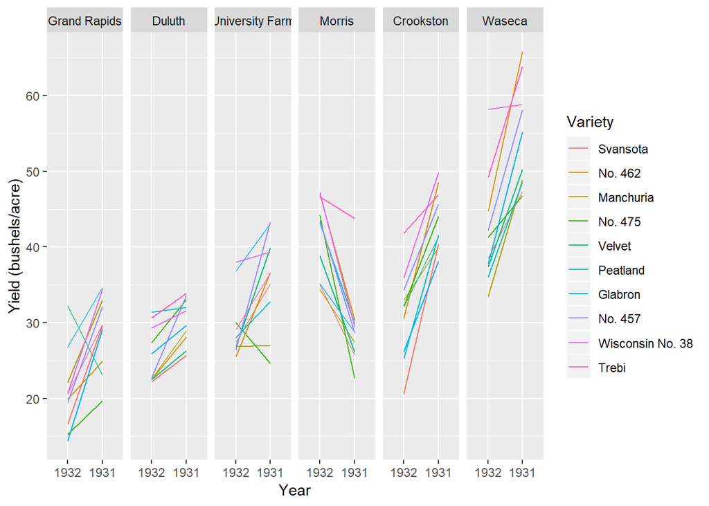

```r
ggplot(barley, aes(x = year, y = yield, col = variety, group = variety)) +
  geom_line() +
  facet_wrap(~site, nrow = 1) +
  scale_x_discrete('Year') +
  scale_y_continuous('Yield (bushels/acre)') +
  scale_color_discrete('Variety')
```

Second Alternative:

- If we are not interested in the individual varieties, but rather on the farms, we can make these plots.
  - Using `geom = 'errorbar'` need to add some dodging.
  - Using `geom = 'ribbon'`
- Use some summary statistic, like the mean and standard deviation.

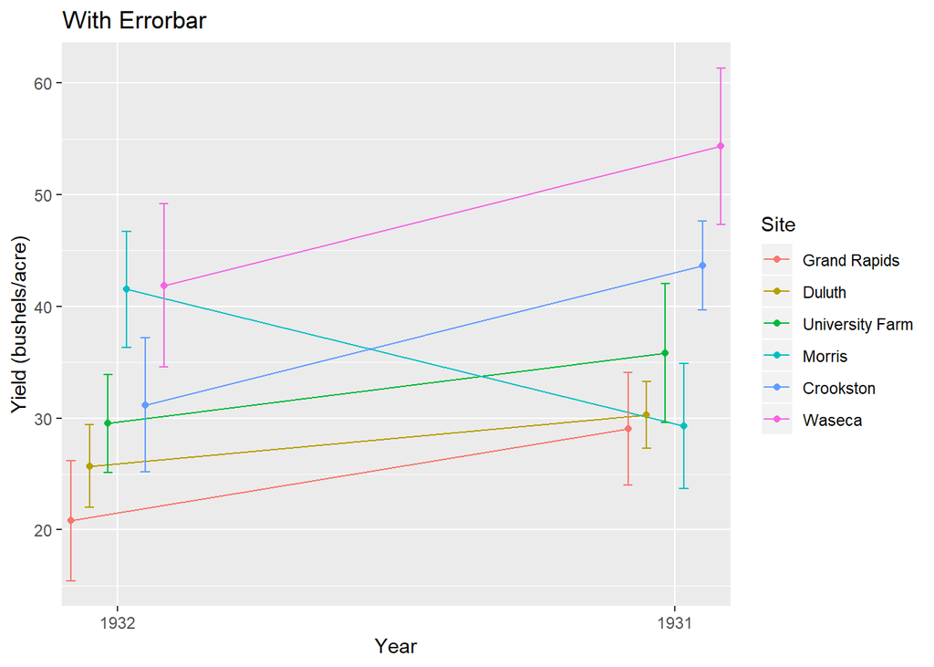

```r
ggplot(barley, aes(x = year, y = yield, col = site, fill = site, group = site)) +
  stat_summary(fun.y = mean, geom = 'line', position = position_dodge(width = 0.2)) +
  stat_summary(fun.y = mean, geom = 'point',position = position_dodge(width = 0.2)) +
  # fun.args = list(mult = 1) to have a errorbar that spans over one standard deviation in both directions.
  stat_summary(fun.data = mean_sdl, fun.args = list(mult = 1), geom = 'errorbar', width = 0.1, position = position_dodge(width = 0.2)) +
  scale_x_discrete('Year', expand = c(0.05, 0.05)) +
  scale_y_continuous('Yield (bushels/acre)') +
  scale_color_discrete('Site') +
  scale_fill_discrete('Site') +
  ggtitle('With Errorbar')
```

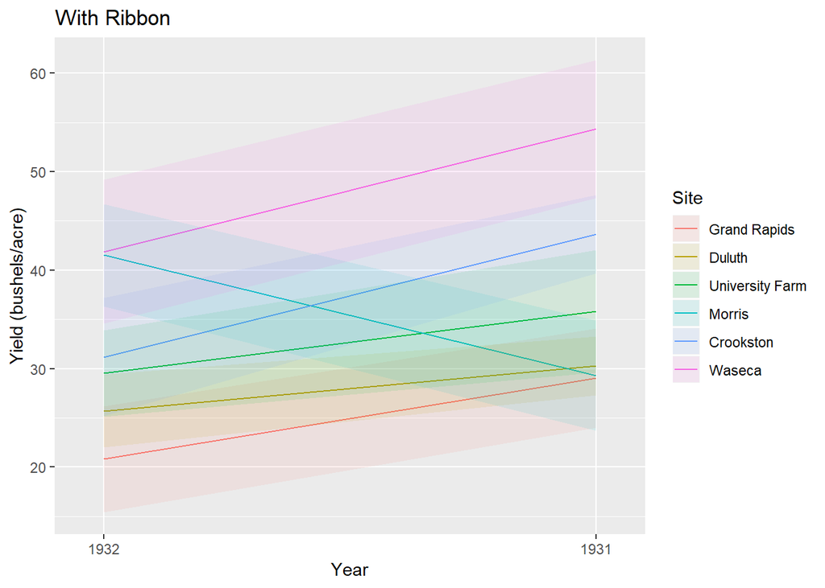

```r
ggplot(barley, aes(x = year, y = yield, col = site, fill = site, group = site)) +
  stat_summary(fun.y = mean, geom = 'line') +
  stat_summary(fun.data = mean_sdl, fun.args = list(mult = 1), geom = 'ribbon', alpha = 0.1, col = NA) +
  scale_x_discrete('Year', expand = c(0.05, 0.05)) +
  scale_y_continuous('Yield (bushels/acre)') +
  scale_color_discrete('Site') +
  scale_fill_discrete('Site') +
  ggtitle('With Ribbon')
```

# **Case Study - Mosaic Plots**

We’ll use `2009 CHIS adult-response dataset` for data visualization here.  
Let’s get familiar with the dataset now.

| Column Name | Description |
| --- | --- |
| RBMI | BMI Category description |
| BMI_P | BMI value |
| RACEHPR2 | race |
| SRSEX | sex |
| SRAGE_P | age |
| MARIT2 | Marital status |
| AB1 | General Health Condition |
| ASTCUR | Current Asthma Status |
| AB51 | Type I or Type II Diabetes |
| POVLL | Poverty level |

## Chi-Squared Test & Mosaic PLots

> `Observation`: The **[Contingency Table](https://bourbon0212.github.io/NTU-CS-X/Week2/Exploratory_Data_Analysis.html#1)** we applied **Chi-Squared Test**  
> `Expected`: The expected values under the null hypothesis of equal proportions.  
> `Residuals`: The difference between the observed data and the expected values

Here’s a table comparing gender and political affiliation, and let’s apply Chi-Squared Test on it.

- Observation

```r
# Make a table manually
party <- matrix(c(762, 327, 468, 484, 239, 477), ncol = 3, byrow = T)
colnames(party) <- c('Democrat', 'Independent', 'Republican')
rownames(party) <- c('F', 'M')
party <- as.table(party)
# Obsrvation
party
```

```
##   Democrat Independent Republican
## F      762         327        468
## M      484         239        477
```

- Expected

```r
# Expected
chisq.test(party)$expected
```

```
##   Democrat Independent Republican
## F 703.6714    319.6453   533.6834
## M 542.3286    246.3547   411.3166
```

- Residuals

```r
# Residuals
chisq.test(party)$residuals
```

```
##     Democrat Independent Republican
## F  2.1988558   0.4113702 -2.8432397
## M -2.5046695  -0.4685829  3.2386734
```

When we perform a **Chi-squared test**, the results are provided to us with the expected & **residuals**.  
And **Mosaic Plot** is just a method to visualize Chi-Squared Test.

- Example of Mosaic Plot

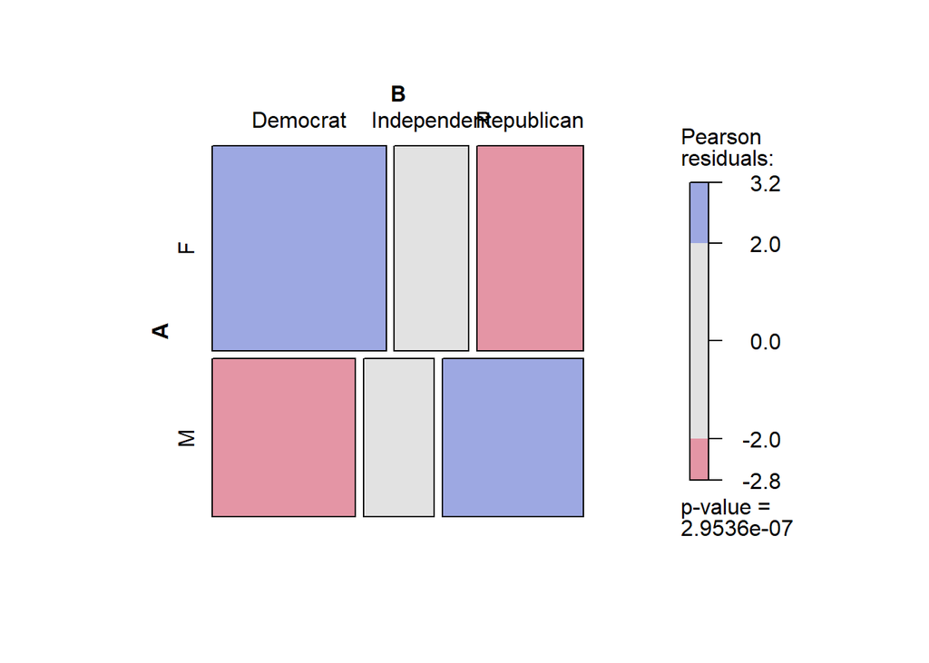

```r
library(vcd)
mosaic(party, shade = T, color = T)
```

- Conclusion
  - The **higher** the residual, the **more overrepresented** a segment is.
  - The **lower** the residual, the **more underrepresented** a segment is.

> A mosaic plot shows us not only the proportional size of each group in a contingency table, but we can also use it to report on the underlying statistics.

##### **To Be Continued with [Data Visualization with ggplot2 (Part 3)](https://bourbon0212.github.io/NTU-CS-X/Week4/Data_Visualization_with_ggplot2__Part_3_.html)**